# wingen-vignette

```r
# Install packages for installing other packages
if (!require("devtools", quietly = TRUE)) install.packages("devtools")

# For wingen:
if (!require("wingen", quietly = TRUE)) devtools::github_install("AnushaPB/wingen")
```

# wingen

```r
library(algatr)
library(wingen)
library(raster)
library(terra)
```

**If using wingen, please cite the following: Bishop A.P., Chambers E.A., Wang I.J. (2023) Generating continuous maps of genetic diversity using moving windows. Methods in Ecology and Evolution. DOI: https://doi.org/10.1111/2041-210X.14090.**

wingen is a package that uses a moving window approach to create continuous maps of genetic diversity. Please see [Bishop et al. 2023](https://doi.org/10.1111/2041-210X.14090) for the paper describing the method, and refer to the [wingen package](https://github.com/AnushaPB/wingen) for further documentation.

Briefly, wingen takes in genetic data (in the form of a vcf), sampling coordinates, and a raster of a given study area. wingen then moves a window (of a user-specified size) across the landscape, and calculates genetic diversity for any samples that fall within this window. The focal cell (the size of which is determined by the raster layer inputted) is then assigned this resulting genetic diversity value, and the window continues sliding across the landscape. Users are able to specify not only window size, but can also aggregate cells to increase map continuity and decrease computational time, and can perform rarefaction of samples such that uneven sampling does not bias calculations. The resulting wingen map can be smoothed using kriging, and any areas that were undersampled (or fall outside an area of interest, such as a species range, for example) are masked.

There are five key functions within wingen:

- `preview_gd()` provides a reference point for what the window and focal cell look like relative to the landscape; this function also allows users to visualize the sample count in each cell given the parameters
- `window_gd()` to create a map of genetic diversity
- `krig_gd()` for spatial interpolation (smoothing) of the resulting map using kriging
- `mask_gd()` to mask out any undersampled areas (or areas that are not of interest)
- `plot_gd()` to plot resulting genetic diversity map and `plot_count()` to plot the resulting sample count map

### Read in and process input data

wingen requires a vcf, sampling coordinates, and a raster layer upon which to move the sliding window across. We’ll also want the shape of California for subsequent plotting, so we’ll save one of the environmental PC layers as a SpatRaster object for this purpose.

```r
load_algatr_example()
```

```
#>
#> ---------------- example dataset ----------------
#>
#> Objects loaded:
#> *liz_vcf* vcfR object (1000 loci x 53 samples)
#> *liz_gendist* genetic distance matrix (Plink Distance)
#> *liz_coords* dataframe with x and y coordinates
#> *CA_env* RasterStack with PC environmental layers
#>
#> -------------------------------------------------
#>
#>
```

```r
envlayer <- rast(CA_env$CA_rPCA1)
```

### Generate raster layer for sliding window

Although we can use one of the PCs within our CA_env object as a raster for wingen, the resolution of those layers is unnecessarily high given our sampling localities, and running wingen (particularly the kriging step) will take a very long time. To remedy this, we can generate a raster layer using the `coords_to_raster()` function in algatr by providing our sampling coordinates. Using this function, we can specify the resolution of our raster with the `res` argument.

```r
liz_lyr <- coords_to_raster(liz_coords, res = 0.5, buffer = 5)
```

## Moving window calculations using `preview_gd()` and `window_gd()`

The `window_gd()` function takes in a vcf file (the `vcf` argument), sampling coordinates (`coords` argument), and a RasterLayer for the window to move across (the `lyr` argument), and the genetic diversity summary statistic to calculate (the `stat` argument); choices are allelic richness (`"allelic.richness"` or `"biallelic.richness"`), nucleotide diversity (`"pi"`), or average heterozygosity (`"Ho"`). For more options for file types and statistics see the original wingen vignette.

There are a number of additional arguments within this function, and the wingen package documentation provides extensive explanations (and guidelines for testing) these parameters. Briefly, `fact` aggregates the input raster layer (by a given factor), `wdim` specifies the window dimensions, `rarify` specifies whether the user would like samples to be rarified (which then requires users to specify `rarify_n` and `rarify_nit`), and finally `parallel` specifies whether you would like to parallelize.

### Preview the moving window

```r
par(mfrow = c(1, 2), oma = rep(1, 4), mar = rep(2, 4))
preview_gd(liz_lyr,
  liz_coords,
  wdim = 3,
  fact = 0
)
```

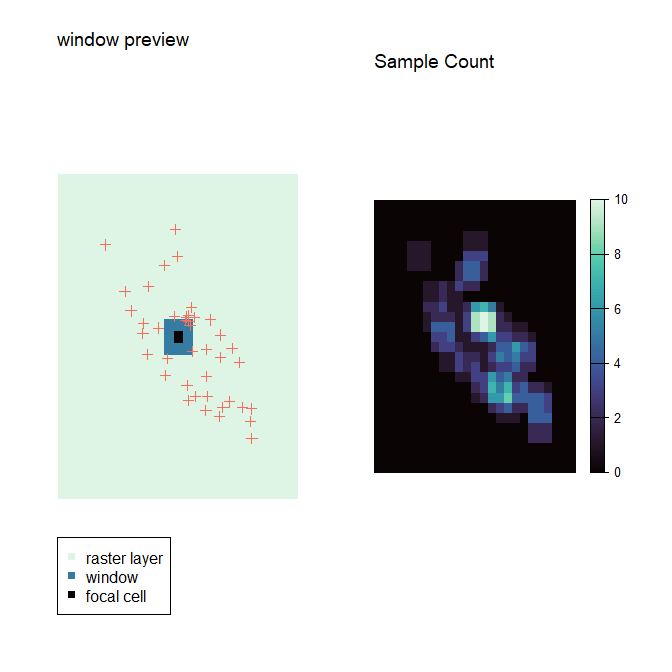

```
#> class       : SpatRaster
#> dimensions  : 27, 25, 1  (nrow, ncol, nlyr)
#> resolution  : 0.5, 0.5  (x, y)
#> extent      : -126.5408, -114.0408, 30.372, 43.872  (xmin, xmax, ymin, ymax)
#> coord. ref. :
#> source(s)   : memory
#> name        : sample_count
#> min value   :            0
#> max value   :           10
```

### Run the moving window

Next, let’s run the moving window function (`window_gd()`) using the parameters specified above, calculating nucleotide diversity (`stat = "pi"`) as our diversity metric. For simplicity’s sake, we will not perform rarefaction of our samples (`rarify = FALSE`, which is the default).

```r
wgd <- window_gd(liz_vcf,
  liz_coords,
  liz_lyr,
  stat = "pi",
  wdim = 3,
  fact = 0
)
```

## Visualizing wingen results

### Plot wingen results with `plot_gd()` and `plot_count()`

wingen allows for plotting maps in two ways: `plot_gd()` plots the genetic diversity layer, while `plot_count()` plots the sample count layer. We can also provide a background map using the `bkg` argument.

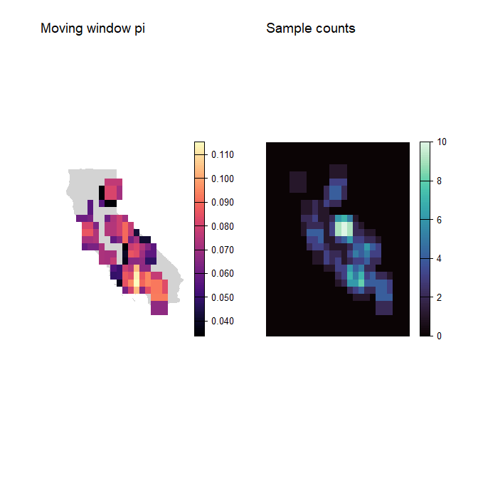

```r
par(mfrow = c(1, 2), oma = rep(1, 4), mar = rep(2, 4))
# Plot map of pi
plot_gd(wgd, main = "Moving window pi", bkg = envlayer)
# Plot sample count map
plot_count(wgd, main = "Sample counts")
```

### Krige results

Kriging is a type of spatial interpolation that uses a spatial model to provide estimates of genetic diversity from unsampled locations; in the cae of wingen, it also allows for smoother maps of genetic diversity. We can krige our moving window map using the `krig_gd()` function by providing the results from the moving window, and a raster layer upon which kriging is performed (an “interpolation grid”); if no interpolation grid is provided, kriging will be done on the moving window layer. The `index` argument specifies which layer we want to krige across; in our case, we’ll krige both layers 1 (genetic diversity) and 2 (sample counts) of the wgd object because we will eventually want to visualize both kriged maps. Kriging can be computationally intensive, but we can remedy this by aggregating the raster layer upon which kriging is performed using either the `agg_r` or `agg_grd` arguments depending on whether we want to aggregate across the moving window layer or the interpolation grid layer, respectively. In our case, given the resolution of `lyr`, we want to disaggregate by a factor of 5 to get a smoother interpolated surface, so we’ll set `disagg_grd = 5`. If only the moving window layer is provided for kriging, we can use the `disagg_r` argument to set this parameter.

The resulting object, `kgd`, is a RasterStack object containing two layers: our genetic diversity statistic (pi), and our sample count information (sample_count).

```r
kgd <- krig_gd(wgd, index = 1:2, liz_lyr, disagg_grd = 5)
```

```
#> [using ordinary kriging]
#> [using ordinary kriging]
```

```r
summary(kgd)
```

```
#>        pi           sample_count
#>  Min.   :0.03367   Min.   : 0.0000
#>  1st Qu.:0.06715   1st Qu.: 0.0000
#>  Median :0.06728   Median : 0.0000
#>  Mean   :0.06728   Mean   : 0.7127
#>  3rd Qu.:0.06731   3rd Qu.: 0.7078
#>  Max.   :0.11540   Max.   :10.0000
```

Let’s look at the plots for the kriged results, and let’s avoid including the background shape for now (i.e., no `bkg` argument). Note that the overall shape of this kriged map is rectangular because of the `lyr` raster shape.

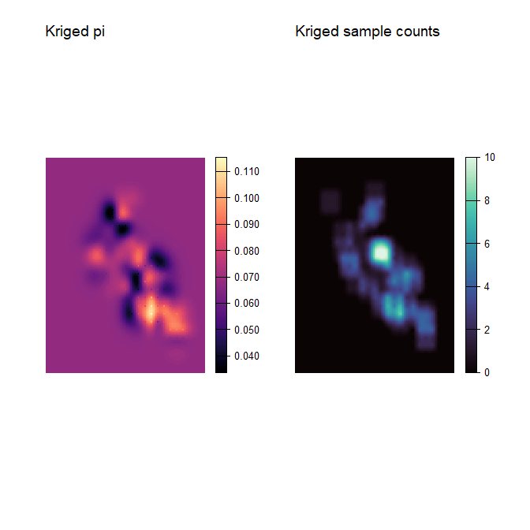

```r
par(mfrow = c(1, 2), oma = rep(1, 4), mar = rep(2, 4))
# Plot kriged map of pi
plot_gd(kgd, main = "Kriged pi")
# Plot kriged sample count map
plot_count(kgd, main = "Kriged sample counts")
```

### Mask using sample counts

Finally, we may want to mask out any areas that we’re not interested in using the `mask_gd()` function. wingen provides several ways to perform masking, but we will focus on two for this vignette. The `mask_gd()` function is quite simple in that it takes in the layer you want masked (`kgd`, in our case) and the layer you want to mask to. Let’s first mask areas based on sample count. Recall that above, we called `krig_gd()` using indices 1 and 2, which told wingen to krige on both the genetic diversity (pi) and sample count layers. We’ll make use of the kriged sample count layer now by masking according to it. The `minval` argument specifies the minimum value below which areas will be masked, meaning that any areas that do not contain any samples will be masked. Let’s compare two maps masked in this way with differing `minval` values.

As you can see, more areas are masked as we increase `minval`.

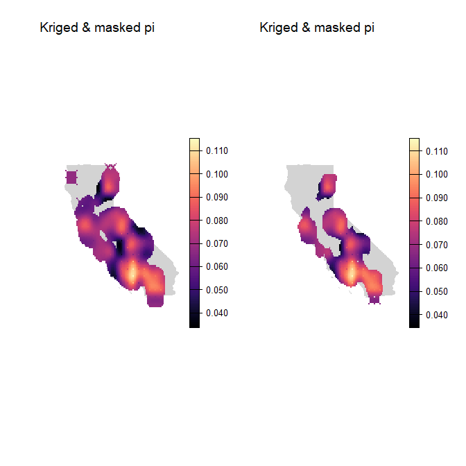

```r
mgd_1 <- mask_gd(kgd, kgd[["sample_count"]], minval = 1)
mgd_2 <- mask_gd(kgd, kgd[["sample_count"]], minval = 2)

par(mfrow = c(1, 2), oma = rep(1, 4), mar = rep(2, 4))
plot_gd(mgd_1, main = "Kriged & masked pi", bkg = envlayer)
plot_gd(mgd_2, main = "Kriged & masked pi", bkg = envlayer)
```

### Mask using state boundaries

Next, let’s mask out any areas outside of California state boundaries using our `envlayer` object.

One thing to keep in mind is that if you are masking using a raster, you need to ensure that pixels match between the object to be masked and the object to use as a mask. If they aren’t the same, or if their extents are different, you will either get an error or the map will look wonky. To remedy this, we can use terra’s `resample()` function. This function will resample a raster (here, `envlayer`) based on an inputted raster (here, `mgd_1`).

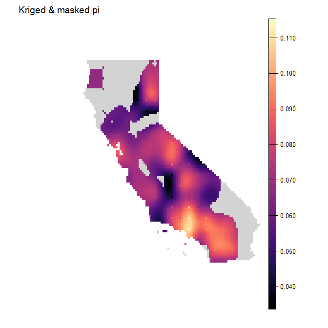

```r
# Resample envlayer based on masked layer
r <- terra::resample(envlayer, mgd_1)

# Perform masking
mgd <- mask_gd(mgd_1, r)

# Plot masked map
plot_gd(mgd, main = "Kriged & masked pi", bkg = r)
```

## Running wingen with `wingen_do_everything()`

The algatr package also has an option to run all of the above functionality in a single function, `wingen_do_everything()`. If you want to take a look at the preview first, you can set `preview = TRUE`; to krige, set `kriged = TRUE`, and to mask, set `masked = TRUE`. If `preview` is set to TRUE, the preview plot will be printed and a user can enter into the console whether they would like to continue the wingen run with existing parameter settings, or else halt the run. **Please be aware that the `do_everything()` functions are meant to be exploratory. We do not recommend their use for final analyses unless certain they are properly parameterized.**

**WARNING: Many wingen arguments are excluded from `wingen_do_everything()` to reduce the number of arguments in the function. Thus, we strongly advise against using this function for actual analyses and encourage users to explore and test the individual wingen functions given their datasets.**

Below, we’ll run wingen with the following:

- No preview generated before running wingen (`preview = FALSE`)
- Window size of 3x3 (`wdim = 3`), no aggregation factor for moving window (`fact = 0`)
- Pi as our genetic diversity statistic (`stat = "pi"`); this is also the default
- No rarefaction (`rarify = FALSE`)
- Kriging (of both genetic diversity and sample count layers; `kriged = TRUE` and `index = 1:2`) with a disaggregation factor of 4 for kriging (`disagg_grd = 4`)
- Masking to California state boundaries (`mask = envlayer`)
- Plot kriged and masked sample count (`plot_count = TRUE`)

```
#> Please be aware: the do_everything functions are meant to be exploratory. We do not recommend their use for final analyses unless certain they are properly parameterized.
#> CRS do not match
```

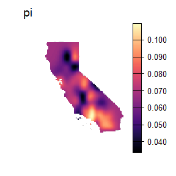

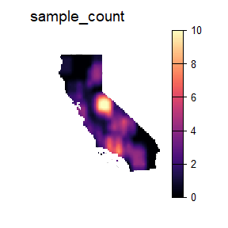

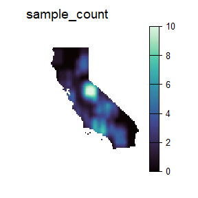

```r
results <- wingen_do_everything(
  gen = liz_vcf,
  lyr = liz_lyr,
  coords = liz_coords,
  wdim = 3,
  fact = 0,
  sample_count = TRUE,
  preview = FALSE,
  min_n = 2,
  stat = "pi",
  rarify = FALSE,
  kriged = TRUE,
  grd = liz_lyr,
  index = 1:2,
  agg_grd = NULL, disagg_grd = 4,
  agg_r = NULL, disagg_r = NULL,
  masked = TRUE, mask = envlayer,
  bkg = envlayer, plot_count = TRUE
)
```

## Additional documentation and citations

|  | Citation/URL | Details |
| --- | --- | --- |
| Manuscript with method | [Bishop et al. 2023](https://doi.org/10.1111/2041-210X.14090) | Paper describing wingen methodology and package |
| R package documentation | [Available on Github](https://github.com/AnushaPB/wingen) | Code, vignette |

Retrieve wingen’s vignette:

```r
# vignette("wingen-vignette")
```